# R Stan examples: IQ recovery after TBI

Georges Monette

York University

March 29, 2017 at 06:59

## Stan for Asymptotic Recovery Curves

We can use non-linear mixed effects models for normally distributed responses to estimate asymptotic recovery curves for VIQ and PIQ separately. It’s feasible to extend these models to handle VIQ and PIQ as a multivariate response, but doing so is not straighforward.

Here, we use Stan to build a model for a multivariate response which will allow us to compare the parameters for the two models in a way that exploits the covariance between the responses.

We start with univariate models which we then combine into a multivariate model.

Loading packages:

```r
library(spida2)
library(magrittr, pos = 1000)
library(lattice)
library(latticeExtra)

library(rstan)
rstan_options(auto_write = TRUE)
options(mc.cores = parallel::detectCores())
```

## Explore data

```r
data(iq)
?iq
head(iq)
```

```
  DAYSPC DCOMA  SEX    AgeIn   ID PIQ VIQ
1     30     4 Male 20.67077 3358  87  89
2     16    17 Male 55.28816 3535  95  77
3     40     1 Male 55.91513 3547  95 116
4     13    10 Male 61.66461 3592  59  73
5     19     6 Male 30.12731 3728  67  73
6     13     3 Male 57.06229 3790  76  69
```

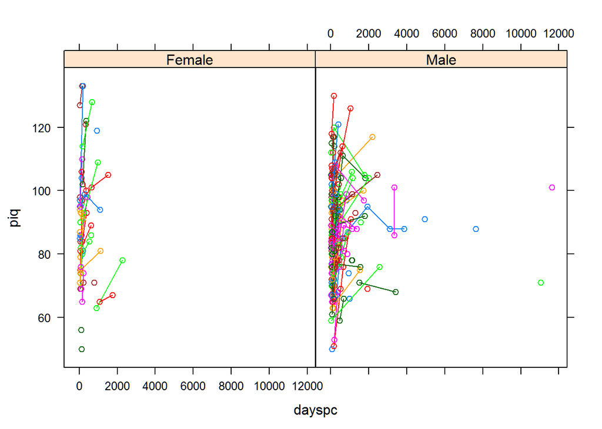

```r
names(iq) <- tolower(names(iq))

dd <-iq

(p <- xyplot(piq ~ dayspc | sex, dd, groups = id, type = 'b'))
```

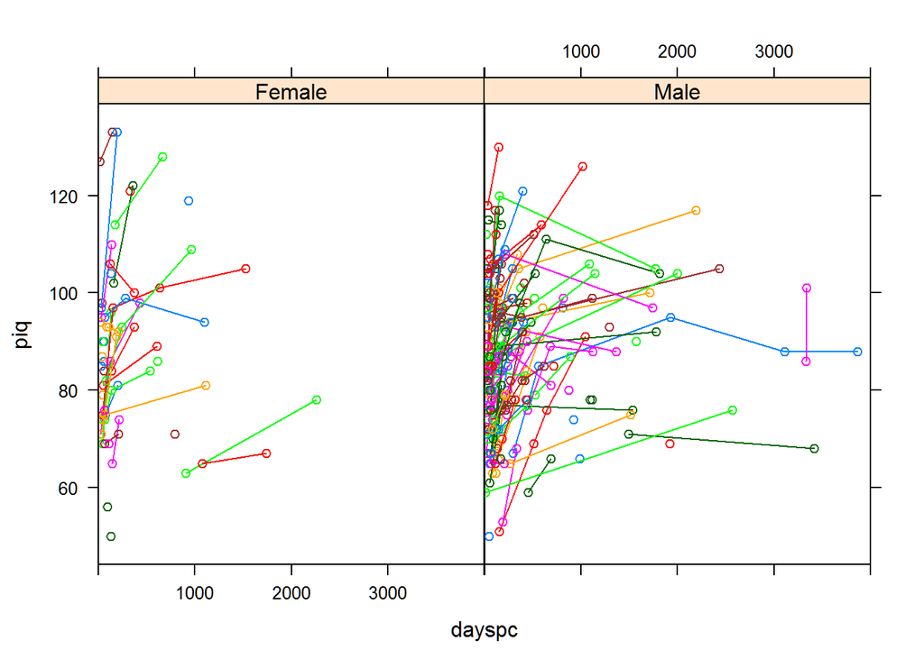

```r
update(p, xlim = c(0,4000))
```

```r
if(interactive) {
  rows <- numeric(0)
  # can repeat:
  trellis.focus()
  rows <- c(rows, panel.identify(labels=dd$id))
  # end
  trellis.unfocus()
  rows
  save(rows, file = 'rows.rda')
}

load('rows.rda', verbose = T)
```

```
Loading objects:
  rows
```

```r
dd[rows,] %>% sortdf(~dcoma+dayspc)
```

```
    dayspc dcoma  sex    agein   id piq viq
47    3333     9 Male 43.93977 2600  86  80
327   3337     9 Male 43.93977 2600 101  84
303   1491    21 Male 22.00684  651  71  94
325   3412    21 Male 22.00684  651  68  92
310   1926   130 Male 28.27379 1939  95 108
321   3111   130 Male 28.27379 1939  88 111
326   3864   130 Male 28.27379 1939  88 105
```

```r
# id = 2600 retested 4 days apart
dd[dd$id %in% dd[rows,'id'],]  %>%  sortdf(~dcoma+dayspc)
```

```
    dayspc dcoma  sex    agein   id piq viq
47    3333     9 Male 43.93977 2600  86  80
327   3337     9 Male 43.93977 2600 101  84
303   1491    21 Male 22.00684  651  71  94
325   3412    21 Male 22.00684  651  68  92
234    295   130 Male 28.27379 1939  67 117
271    562   130 Male 28.27379 1939  85 111
310   1926   130 Male 28.27379 1939  95 108
321   3111   130 Male 28.27379 1939  88 111
326   3864   130 Male 28.27379 1939  88 105
```

```r
if(interactive){
  library(p3d)
  Init3d()
  dd$dcoma.cat <- cut(dd$dcoma, c(-1,2,5,10,20,50,Inf))
  Plot3d( viq ~ piq + log(dayspc) |
            dcoma.cat, dd, groups = id,
          col = heat.colors(6))
  Plot3d( viq ~ log(dcoma+2) + log(dayspc) |
            dcoma.cat, dd, groups = id,
          col = heat.colors(6))
  Plot3d( piq ~ log(dcoma+2) + log(dayspc) |
            dcoma.cat, dd, groups = id,
          col = heat.colors(12)[1:6])
  fg()
  Id3d()
}
```

## Stan program

```r
stanfile <- 'asymp_model_1.stan'
pr <- function(x) print(readLines(x), quote = FALSE) # write a function for repetitive tasks
pr(stanfile)
```

```
 [1]
 [2] // Asymptotic recovery model
 [3] // - random intercept
 [4]
 [5] data {
 [6]   int N;
 [7]   int J;
 [8]   vector[N] y;
 [9]   vector[N] time;
[10]   vector[N] coma;
[11]   int id[N];
[12]   int Np;  // predictor values for prediction
[13]   vector[Np] time_p;
[14]   vector[Np] coma_p;
[15] }
```

[output cut: 27 more lines]

```r
  system.time(
  asymp_model_dso <- stan_model(stanfile)
)
```

```
   user  system elapsed
   0.15    0.00    0.67
```

### Prepare data list

```r
names(dd)
```

```
[1] "dayspc" "dcoma"  "sex"    "agein"  "id"     "piq"    "viq"
```

```
'pars' not specified. Showing first 10 parameters by default.
```

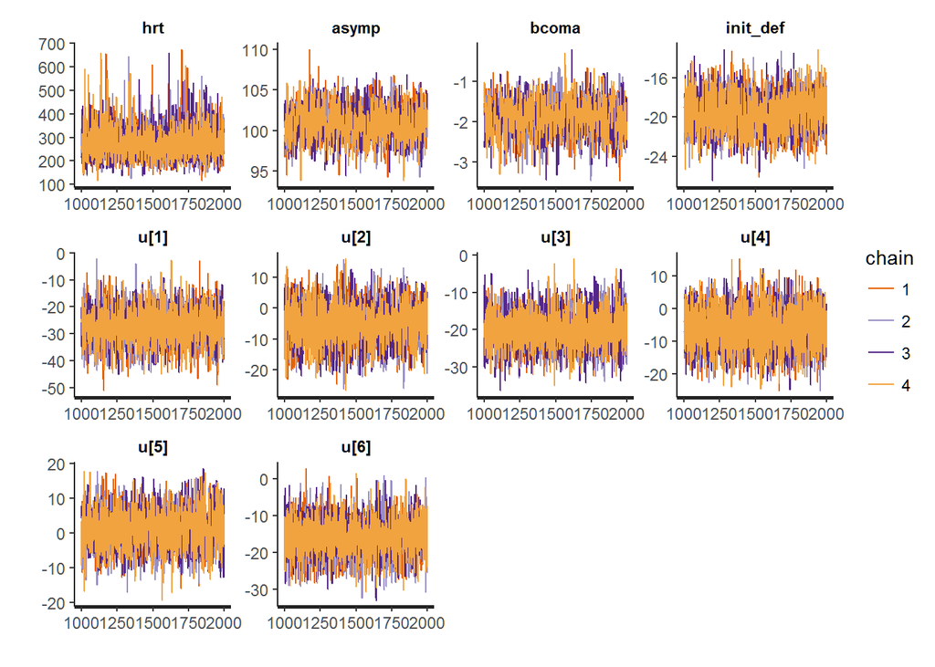

```r
pred <- expand.grid(time=seq(0, 3*365, 30),
                    coma = seq(0,30,5))
dat <- list(
  N = nrow(dd),
  id = nid <- as.numeric(as.factor(dd$id)),
  J = max(nid),
  y = dd$piq,
  time = dd$dayspc,
  coma = sqrt(dd$dcoma),
  Np = nrow(pred),
  time_p = pred$time,
  coma_p = sqrt(pred$coma)
)
set.seed(789723)
mod <- sampling(asymp_model_dso, dat, chains = 4, iter = 2000)
# Note: chains and iter are defaults
traceplot(mod)
```

```r
names(mod)
```

```
  [1] "hrt"              "asymp"            "bcoma"
  [4] "init_def"         "u[1]"             "u[2]"
  [7] "u[3]"             "u[4]"             "u[5]"
 [10] "u[6]"             "u[7]"             "u[8]"
 [13] "u[9]"             "u[10]"            "u[11]"
 [16] "u[12]"            "u[13]"            "u[14]"
 [19] "u[15]"            "u[16]"            "u[17]"
 [22] "u[18]"            "u[19]"            "u[20]"
 [25] "u[21]"            "u[22]"            "u[23]"
 [28] "u[24]"            "u[25]"            "u[26]"
 [31] "u[27]"            "u[28]"            "u[29]"
 [34] "u[30]"            "u[31]"            "u[32]"
 [37] "u[33]"            "u[34]"            "u[35]"
 [40] "u[36]"            "u[37]"            "u[38]"
 [43] "u[39]"            "u[40]"            "u[41]"
```

[output cut: 141 more lines]

```r
pars <- grepv('^u|y_p', names(mod), invert = T)
pars
```

```
[1] "hrt"              "asymp"            "bcoma"
[4] "init_def"         "sigma"            "sigma_u"
[7] "estd_reliability" "lp__"
```

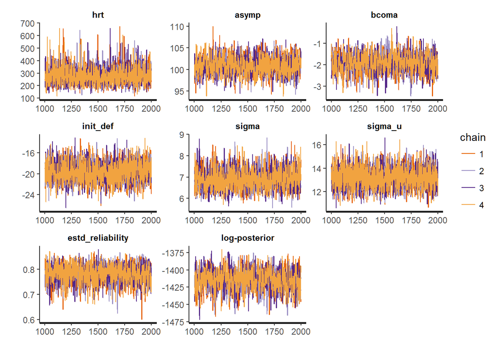

```r
traceplot(mod, pars = pars)
```

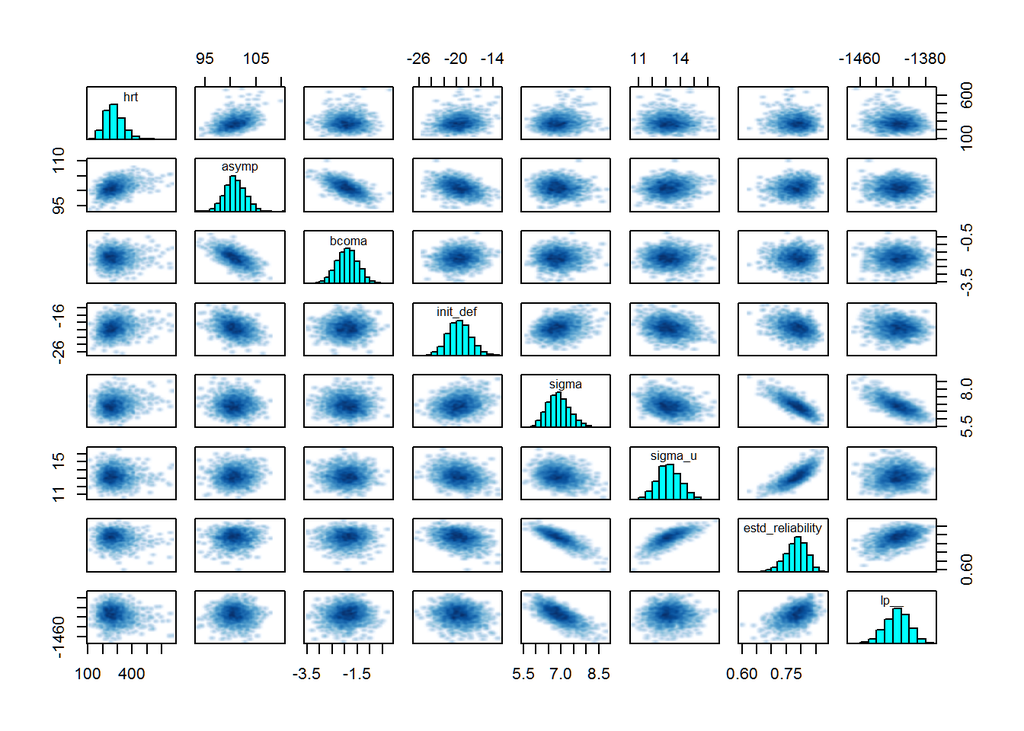

```r
pairs(mod, pars = pars)
```

```r
if(interactive) {
  library(shinystan)
  mod_sso <- launch_shinystan(mod)
}
zd <- as.data.frame(mod, pars = pars)
head(zd)
```

```
       hrt     asymp     bcoma  init_def    sigma  sigma_u
1 248.6616  99.44251 -1.840998 -18.98879 6.113226 14.18239
2 223.4623  96.73326 -1.529614 -20.03282 7.171269 13.00136
3 299.7434 101.48190 -2.009629 -22.73065 7.478259 13.80663
4 237.3620  99.64009 -1.782418 -17.92212 6.566355 13.51232
5 325.5468 103.15033 -2.075279 -22.85777 6.509156 13.31230
6 323.6461 100.91756 -2.137051 -20.48333 6.542990 13.73860
  estd_reliability      lp__
1        0.8433137 -1412.486
2        0.7667308 -1415.284
3        0.7731699 -1411.532
4        0.8089631 -1407.463
5        0.8070505 -1404.843
6        0.8151202 -1403.544
```

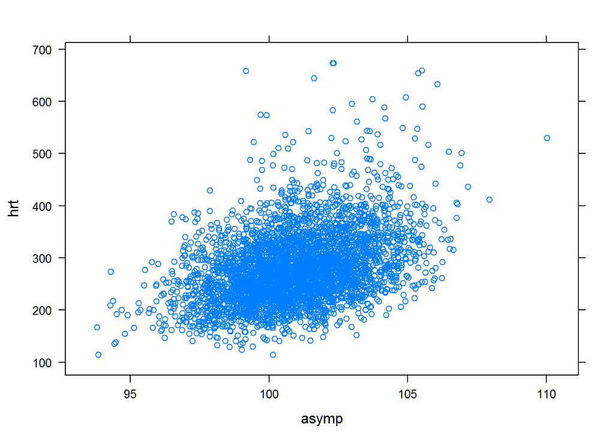

```r
xyplot(hrt~asymp, zd)
```

```r
print(mod, pars = pars)
```

```
Inference for Stan model: asymp_model_1.
4 chains, each with iter=2000; warmup=1000; thin=1;
post-warmup draws per chain=1000, total post-warmup draws=4000.

                     mean se_mean    sd     2.5%      25%      50%
hrt                280.01    1.32 67.36   174.47   233.95   271.88
asymp              100.93    0.06  2.00    97.11    99.59   100.87
bcoma               -1.90    0.01  0.44    -2.77    -2.19    -1.90
init_def           -19.54    0.04  1.86   -23.22   -20.77   -19.57
sigma                6.91    0.01  0.46     6.10     6.59     6.88
sigma_u             13.21    0.01  0.85    11.64    12.64    13.16
estd_reliability     0.78    0.00  0.04     0.71     0.76     0.79
lp__             -1414.76    0.51 15.01 -1446.08 -1424.26 -1414.44
                      75%    97.5% n_eff Rhat
hrt                315.86   432.71  2588    1
asymp              102.26   104.89  1155    1
bcoma               -1.62    -1.07   845    1
init_def           -18.33   -15.85  2244    1
sigma                7.19     7.89  1253    1
sigma_u             13.76    14.97  4000    1
estd_reliability     0.81     0.84  1609    1
lp__             -1404.30 -1386.69   855    1

Samples were drawn using NUTS(diag_e) at Wed Mar 29 06:59:51 2017.
For each parameter, n_eff is a crude measure of effective sample size,
and Rhat is the potential scale reduction factor on split chains (at
convergence, Rhat=1).
```

```r
get_posterior_mean(mod, pars = pars)[,5]
```

```
             hrt            asymp            bcoma         init_def
     280.0060385      100.9283244       -1.9048779      -19.5398004
           sigma          sigma_u estd_reliability             lp__
       6.9074019       13.2059454        0.7832033    -1414.7601528
```

Note that you can do extensive plotting of the posterior sample with ‘shinystan’ including some not highly satisfying 3d plots.

## Random initial deficit

It wasn’t feasible to fit a model that included random initial deficits using ‘lme’ so this will be an interesting experiment.

Note that the data will be identical.

```r
stanfile <- 'asymp_model_2.stan'
pr(stanfile)
```

```
 [1]
 [2] // Asymptotic recovery model
 [3] // - random intercept
 [4]
 [5] data {
 [6]   int N;
 [7]   int J;
 [8]   vector[N] y;
 [9]   vector[N] time;
[10]   vector[N] coma;
[11]   int id[N];
[12]   int Np;  // predictor values for prediction
[13]   vector[Np] time_p;
[14]   vector[Np] coma_p;
[15] }
```

[output cut: 35 more lines]

```r
system.time(
  asymp_model_2_dso <- stan_model(stanfile)
)
```

```
   user  system elapsed
   0.10    0.00    0.09
```

Fitting the model. The data is the same.

```r
mod2 <- sampling(asymp_model_2_dso, dat, chains = 4, iter = 2000)
pars <- grepv('^u|y_p', names(mod2), invert = T)
pars
```

```
[1] "hrt"              "asymp"            "bcoma"
[4] "init_def_mean"    "sigma"            "sigma_u"
[7] "sigma_idef"       "estd_reliability" "lp__"
```

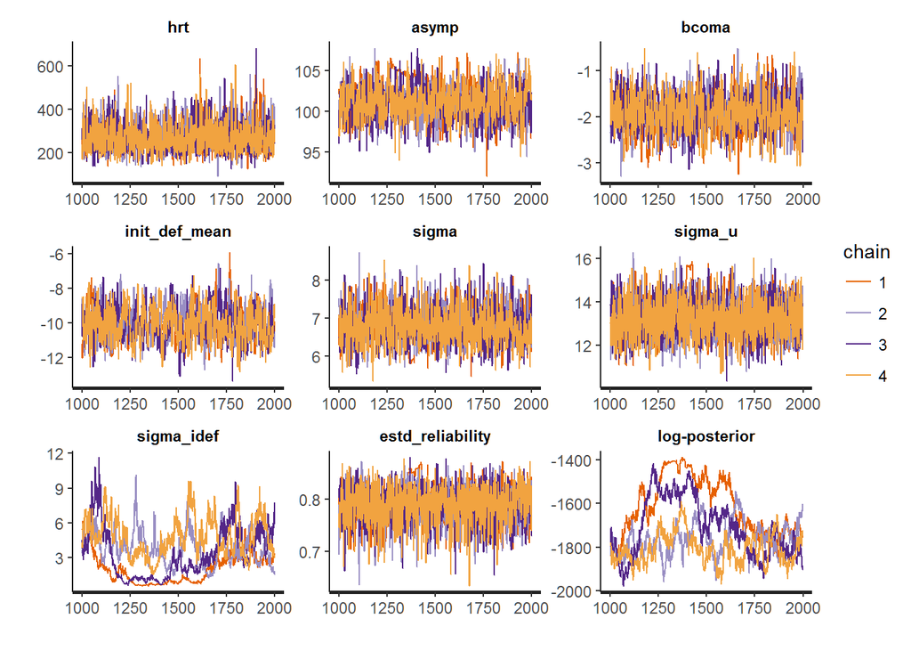

```r
traceplot(mod2, pars = pars)
```

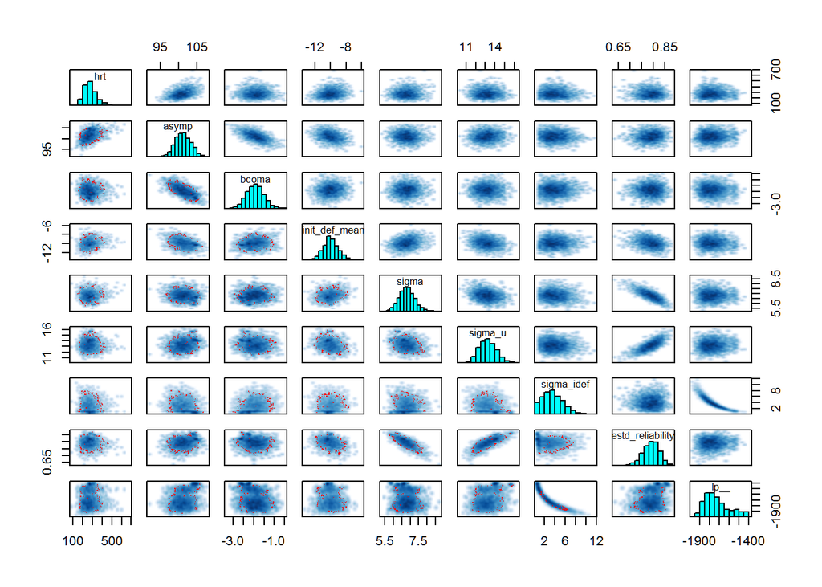

```r
pairs(mod2, pars = pars)
```

### Poor convergence: possible remedies

The variability in the sd of initial deficit is poorly estimated.

We can try to improve this in a least two ways:

1. Reparametrize the model: Taking the initial point at time 0 puts it outside the range of the data. Using a later time as time 0 could improve the estimate. This can be done just by changing the data and subtracting a constant from time. We then need to remember the changed interpretation of parameters although most parameters are not affected, e.g. ‘asymp’ and ‘hrt’
2. Use an informative prior for ‘sigma_idef’. So far all models have used flat priors for hyper-parameters. Gelman would not hesitate to use much more informative priors.

We’ll try step 1 because it’s easy. We’ll subtract 180 from time so that time 0 will be relocated to approximately 6 months.

#### Reparametrize

```r
dat_6 <- list(
  N = nrow(dd),
  id = nid <- as.numeric(as.factor(dd$id)),
  J = max(nid),
  y = dd$piq,
  time = dd$dayspc - 180,
  coma = sqrt(dd$dcoma),
  Np = nrow(pred),
  time_p = pred$time - 180,
  coma_p = sqrt(pred$coma)
)

mod2_6 <- sampling(asymp_model_2_dso, dat_6, chains = 4, iter = 2000)
pars <- grepv('^u|y_p', names(mod2_6), invert = T)
pars
```

```
[1] "hrt"              "asymp"            "bcoma"
[4] "init_def_mean"    "sigma"            "sigma_u"
[7] "sigma_idef"       "estd_reliability" "lp__"
```

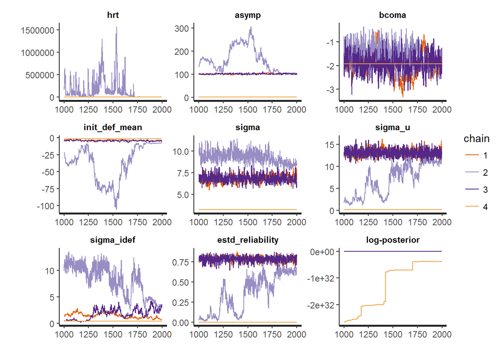

```r
traceplot(mod2_6, pars = pars)
```

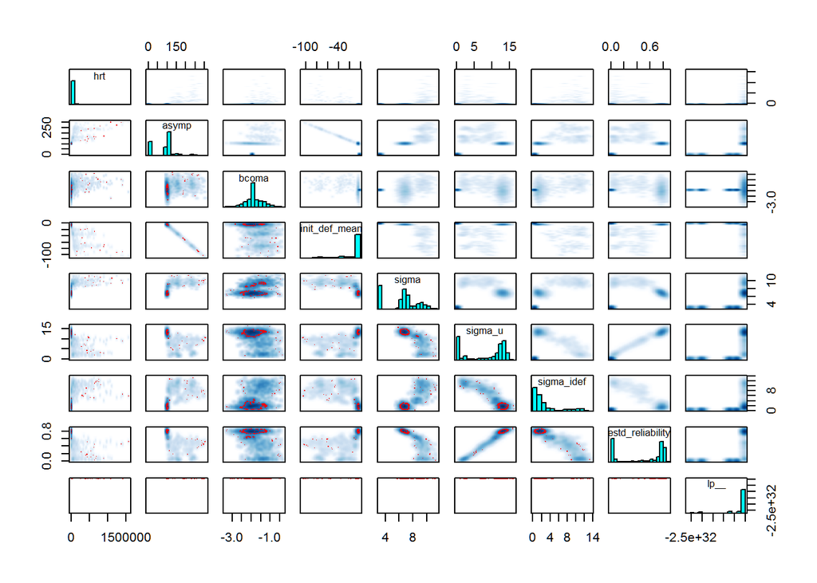

```r
pairs(mod2_6, pars = pars)
```

#### Informative prior

We will try a Gamma prior on ‘sigma_idef’

```r
stanfile <- 'asymp_model_3.stan'
pr(stanfile)
```

```
 [1]
 [2] // Asymptotic recovery model
 [3] // - random intercept
 [4]
 [5] data {
 [6]   int N;
 [7]   int J;
 [8]   vector[N] y;
 [9]   vector[N] time;
[10]   vector[N] coma;
[11]   int id[N];
[12]   int Np;  // predictor values for prediction
[13]   vector[Np] time_p;
[14]   vector[Np] coma_p;
[15]   // gamma prior parameters
```

[output cut: 40 more lines]

```r
system.time(
  asymp_model_3_dso <- stan_model(stanfile)
)
```

```
   user  system elapsed
   0.11    0.04    1.03
```

Fitting the model. The data is the same plus the two parameters for the gamma prior.

```r
mod3_6 <- sampling(asymp_model_3_dso,
                 c(dat_6, gamma_df = 4, gamma_scale = .5),
                 chains = 4, iter = 2000,
                 init = list(
                   list(sigma_idef=1,init_def_mean = -10, asymp = 100),
                   list(sigma_idef=1,init_def_mean = -10, asymp = 100),
                   list(sigma_idef=1,init_def_mean = -10, asymp = 100),
                   list(sigma_idef=1,init_def_mean = -10, asymp = 100)
                 ),
                 control = list(adapt_delta = 0.85))
pars <- grepv('^u|y_p', names(mod3_6), invert = T)
pars
```

```
[1] "hrt"              "asymp"            "bcoma"
[4] "init_def_mean"    "sigma"            "sigma_u"
[7] "sigma_idef"       "estd_reliability" "lp__"
```

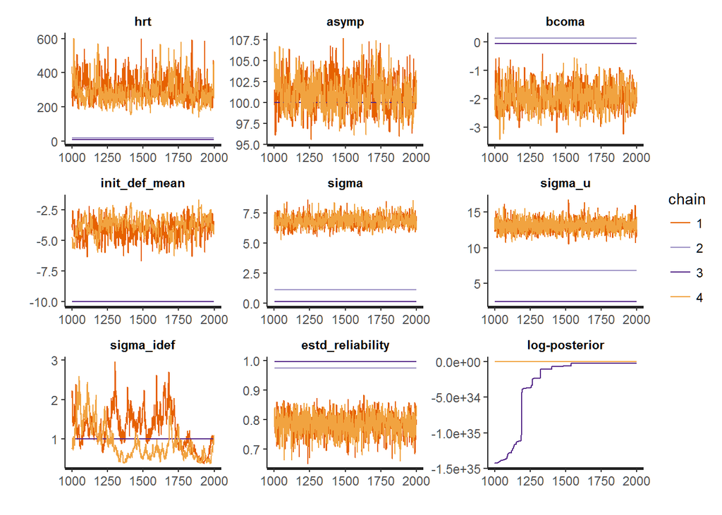

```r
traceplot(mod3_6, pars = pars)
```

[output not shown]

[output cut: 44 more lines]

[output not shown]

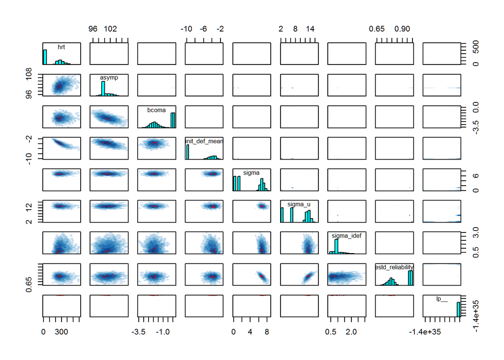

```r
pairs(mod3_6, pars = pars)
```

```r
print(mod3_6, pars = pars)
```

```
Inference for Stan model: asymp_model_3.
4 chains, each with iter=2000; warmup=1000; thin=1;
post-warmup draws per chain=1000, total post-warmup draws=4000.

                          mean      se_mean           sd          2.5%
hrt               1.536100e+02 1.013400e+02 1.493400e+02  6.720000e+00
asymp             1.005500e+02 2.000000e-02 1.510000e+00  9.795000e+01
bcoma            -9.300000e-01 7.000000e-01 1.020000e+00 -2.560000e+00
init_def_mean    -6.960000e+00 2.160000e+00 3.090000e+00 -1.000000e+01
sigma             3.740000e+00 2.220000e+00 3.150000e+00  1.400000e-01
sigma_u           8.890000e+00 3.220000e+00 4.590000e+00  2.410000e+00
sigma_idef        1.040000e+00 1.000000e-02 3.400000e-01  4.600000e-01
estd_reliability  8.900000e-01 7.000000e-02 1.000000e-01  7.200000e-01
lp__             -7.795785e+33 8.879505e+33 2.764534e+34 -1.285225e+35
                          25%           50%      75%    97.5% n_eff  Rhat
hrt               1.40600e+01  8.020000e+01   284.12   424.61     2  3.34
asymp             1.00000e+02  1.000000e+02   101.04   104.37  4000  1.09
bcoma            -1.92000e+00 -2.300000e-01    -0.01     0.14     2  3.69
init_def_mean    -1.00000e+01 -8.320000e+00    -3.87    -2.74     2  5.98
sigma             8.70000e-01  3.180000e+00     6.82     7.66     2 10.31
sigma_u           5.72000e+00  8.640000e+00    13.16    14.57     2  8.20
sigma_idef        9.80000e-01  1.000000e+00     1.00     1.97  4000  1.18
estd_reliability  7.90000e-01  9.300000e-01     0.98     1.00     2  4.52
lp__             -5.83957e+32 -2.388457e+13 -1511.36 -1357.83    10  1.47

Samples were drawn using NUTS(diag_e) at Wed Mar 29 07:08:37 2017.
For each parameter, n_eff is a crude measure of effective sample size,
and Rhat is the potential scale reduction factor on split chains (at
convergence, Rhat=1).
```

```r
get_posterior_mean(mod3_6, pars = pars)[,5] %>% cbind
```

```
                             .
hrt               1.536056e+02
asymp             1.005547e+02
bcoma            -9.328900e-01
init_def_mean    -6.963954e+00
sigma             3.740363e+00
sigma_u           8.890596e+00
sigma_idef        1.037979e+00
estd_reliability  8.850883e-01
lp__             -7.795785e+33
```

```r
get_posterior_mean(mod2_6, pars = pars)[,5] %>% cbind
```

```
                             .
hrt               3.536049e+04
asymp             9.129888e+01
bcoma            -1.835744e+00
init_def_mean    -1.150935e+01
sigma             6.546502e+00
sigma_u           8.377229e+00
sigma_idef        2.946957e+00
estd_reliability  4.816285e-01
lp__             -3.148898e+31
```

```r
get_posterior_mean(mod2, pars = pars)[,5] %>% cbind
```

```
                             .
hrt                277.0336077
asymp              101.2138628
bcoma               -1.9287324
init_def_mean       -9.9841780
sigma                6.7950729
sigma_u             13.2386495
sigma_idef           3.5374468
estd_reliability     0.7893542
lp__             -1724.1087070
```

## Multivariate model for VIQ and PIQ

Instead of simple standard deviations for each VIQ and PIQ, we need covariance matrices to describe the within- and the between-subject covariance between VIQ and PIQ.

The first model uses a uniform prior on covariance matrices using constraints generated by Stan on covariance matrices.

It is more efficient to use a combination of an LKJ prior on correlation together with priors of variances. The second model below use this form of parametrization.

```r
stanfile <- 'asymp_model_4.stan'
pr(stanfile)
```

```
 [1] //
 [2] //  Multivariate model for VIQ and PIQ
 [3] //
 [4]
 [5] data {
 [6]   int N;
 [7]   int J;
 [8]   matrix[N,2] iq;
 [9]   vector[N] time;
[10]   vector[N] coma;
[11]   int id[N];
[12] }
[13] transformed data{
[14]   real ln2;
[15]   vector[2] zero;
```

[output cut: 31 more lines]

```r
system.time(
  asymp_model_4_dso <- stan_model(stanfile)
)
```

```
hash mismatch so recompiling; make sure Stan code ends with a blank line
```

[output not shown]

```
   user  system elapsed
   0.58    0.08   93.64
```

### Data for multivariate model

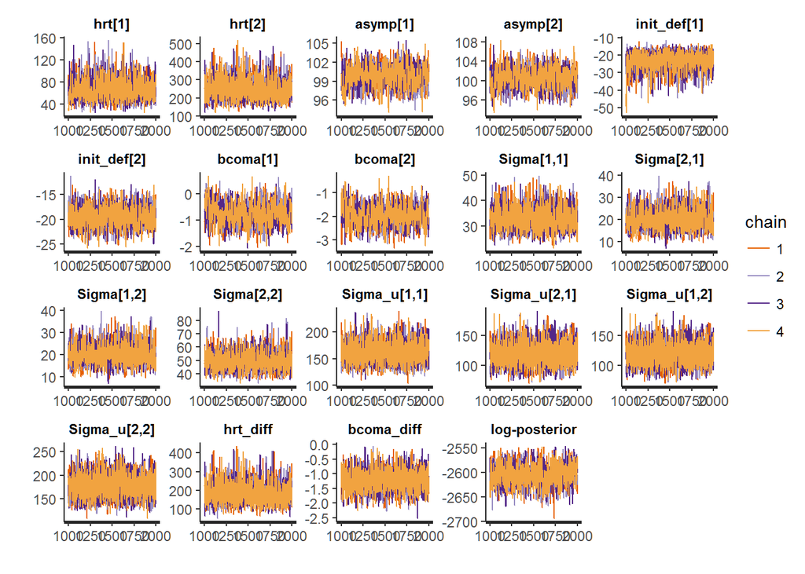

```r
dat <- list(
  N = nrow(dd),
  id = nid <- as.numeric(as.factor(dd$id)),
  J = max(nid),
  iq = cbind(dd$viq,dd$piq),
  time = dd$dayspc,
  coma = sqrt(dd$dcoma)
)

mult_mod <- sampling( asymp_model_4_dso, dat)

pars <- grepv('^u' ,names(mult_mod), invert = T)
traceplot(mult_mod, pars = pars)
```

```
the following parameters were dropped because they are duplicative
Sigma[1,2] Sigma_u[1,2]
```

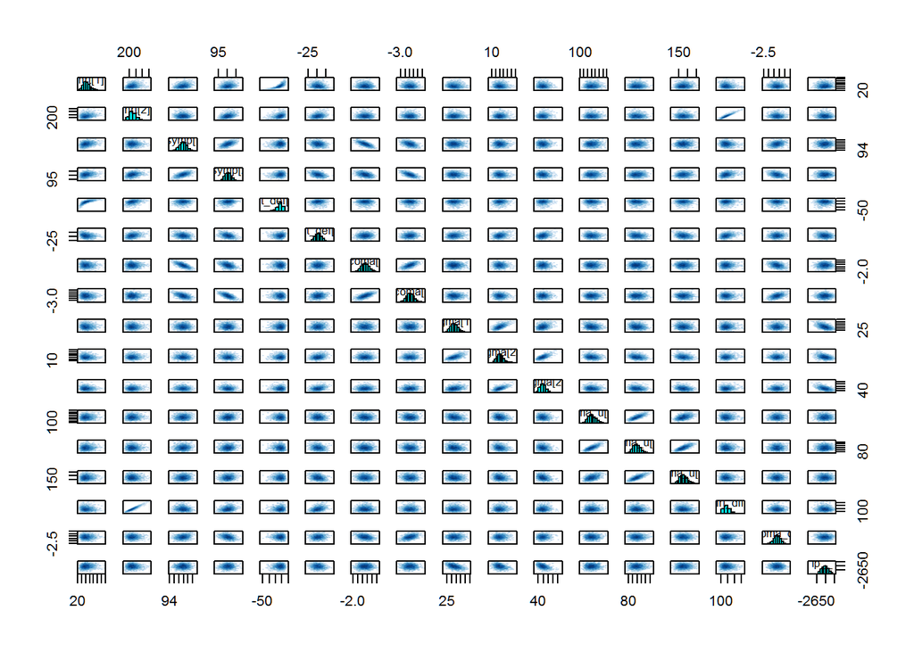

```r
pairs(mult_mod, pars = pars)
```

```r
print(mult_mod, pars = pars)
```

```
Inference for Stan model: asymp_model_4.
4 chains, each with iter=2000; warmup=1000; thin=1;
post-warmup draws per chain=1000, total post-warmup draws=4000.

                 mean se_mean    sd     2.5%      25%      50%      75%
hrt[1]          65.18    0.42 18.23    36.67    52.36    62.78    75.12
hrt[2]         249.32    1.02 53.51   160.66   211.31   244.72   279.99
asymp[1]        99.79    0.06  1.61    96.57    98.73    99.80   100.87
asymp[2]       100.53    0.07  1.97    96.62    99.23   100.52   101.86
init_def[1]    -23.34    0.12  4.88   -34.91   -25.94   -22.77   -20.00
init_def[2]    -19.46    0.04  1.95   -23.17   -20.77   -19.52   -18.15
bcoma[1]        -0.72    0.02  0.40    -1.50    -0.99    -0.72    -0.44
bcoma[2]        -1.93    0.02  0.42    -2.78    -2.22    -1.94    -1.64
Sigma[1,1]      33.16    0.10  4.19    25.82    30.24    32.82    35.79
Sigma[2,1]      20.38    0.12  4.22    13.02    17.47    20.00    22.96
Sigma[1,2]      20.38    0.12  4.22    13.02    17.47    20.00    22.96
Sigma[2,2]      49.72    0.17  6.55    38.23    45.07    49.34    53.68
Sigma_u[1,1]   162.62    0.31 19.63   128.29   148.57   160.99   175.41
Sigma_u[2,1]   119.42    0.34 18.19    86.67   106.59   118.38   131.11
Sigma_u[1,2]   119.42    0.34 18.19    86.67   106.59   118.38   131.11
Sigma_u[2,2]   176.27    0.43 22.67   135.45   160.26   174.76   191.17
hrt_diff       184.14    0.93 52.12    99.58   147.66   178.34   213.67
bcoma_diff      -1.22    0.01  0.33    -1.88    -1.44    -1.22    -1.01
lp__         -2604.98    0.66 20.41 -2644.44 -2619.18 -2605.04 -2590.67
                97.5% n_eff Rhat
hrt[1]         108.37  1867 1.00
hrt[2]         373.35  2741 1.00
asymp[1]       102.86   639 1.01
asymp[2]       104.38   818 1.00
init_def[1]    -15.66  1633 1.00
init_def[2]    -15.57  1916 1.00
bcoma[1]         0.05   565 1.00
bcoma[2]        -1.11   629 1.00
Sigma[1,1]      42.37  1632 1.00
Sigma[2,1]      29.64  1298 1.00
Sigma[1,2]      29.64  1298 1.00
Sigma[2,2]      63.89  1446 1.00
Sigma_u[1,1]   202.97  4000 1.00
Sigma_u[2,1]   158.27  2916 1.00
Sigma_u[1,2]   158.27  2916 1.00
Sigma_u[2,2]   224.59  2766 1.00
hrt_diff       303.20  3125 1.00
bcoma_diff      -0.56  3120 1.00
lp__         -2565.84   945 1.00

Samples were drawn using NUTS(diag_e) at Wed Mar 29 07:25:38 2017.
For each parameter, n_eff is a crude measure of effective sample size,
and Rhat is the potential scale reduction factor on split chains (at
convergence, Rhat=1).
```

## Using a Cholesky parametrization